# Abundance

Jackson Evans

10/7/2021

```r
library("ggplot2")
library(dplyr)
library(tidyverse)
library(gmp)
library(plyr)
```

Let’s take a look at the distribution of abundant numbers.

First, here is a function from stackxchange that provides a list of all the factors of an integer input.

```r
get_all_factors <- function(n)
{
  prime_factor_tables <- lapply(
    setNames(n, n),
    function(i)
    {
      if(i == 1) return(data.frame(x = 1L, freq = 1L))
      plyr::count(as.integer(gmp::factorize(i)))
    }
  )
  lapply(
    prime_factor_tables,
    function(pft)
    {
      powers <- plyr::alply(pft, 1, function(row) row$x ^ seq.int(0L, row$freq))
      power_grid <- do.call(expand.grid, powers)
      sort(unique(apply(power_grid, 1, prod)))
    }
  )
}
```

Let’s try with integers up to 20,000

```r
number_vector<-c(1:20000)
sigma_vector<-NULL
for (i in number_vector){
  sigma_vector[i]<-sum(unlist(get_all_factors(i)))
}
abundant_vector<-NULL
for (i in number_vector){
  abundant_vector[i]<-case_when(sigma_vector[i]>2*number_vector[i]~1,
                                sigma_vector[i]<=2*number_vector[i]~0)
}
prev_vector<-NULL
for(i in number_vector){
  prev_vector[i]<-sum(abundant_vector[1:i])
}

abundant_graphing<-data.frame(number=number_vector, sigma=sigma_vector,
                              abundant=abundant_vector, prev=prev_vector)
```

This could be more elegant by mutating and piping, but it gets the job done. This creates a data frame with columns of the number, its sigma function result, whether or not it is abundant, and a column summing the number of abundant numbers up to and including the given integer. We want to see how this changes over time, so making a line graph is optimal to see trends going forward or plateaus.

Let’s graph the first 20,000 numbers.

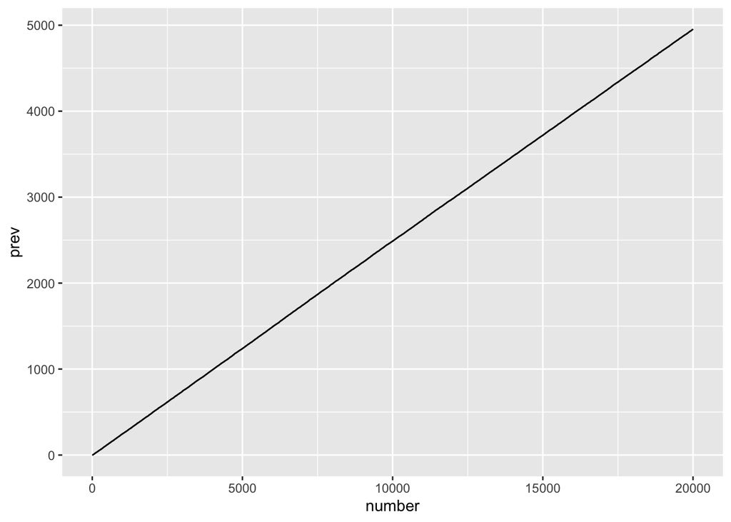

```r
abundant_graphing%>%
  ggplot()+
  geom_line(aes(x=number, y=prev))
```

This seems to follow almost exactly a y=x/4 line. Perhaps there is something wrong? Let’s check some more granular values.

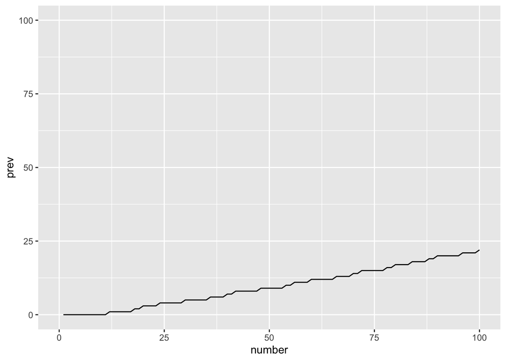

```r
abundant_graphing%>%
  ggplot()+
  geom_line(aes(x=number, y=prev))+
  scale_x_continuous(limits = c(0, 100)) +
  scale_y_continuous(limits = c(0, 100))
```

After some research, this is supported by analysis!

“Theorem (Kobayashi, 2010) For the density of abundant numbers, we have 0.24761 < 1 − Ds(1) < 0.24765. So just under 1 in every 4 natural numbers is abundant, and just over 3 in 4 are deficient.” This is sourced from the University of Georgia (http://pollack.uga.edu/INTEGERS2013.pdf)

Would love to know if you knew of other research or proofs of this! I was just curious about this in class and threw something together.